# LTMLE data example

18-04-2024

This provides a simulated example to prepare what could be real data for a TMLE analysis.

All analyses are based on R and primarily using data.table for data management

The assumption is that the real raw data are found in several tables representing baseline covariates, outcomes and treatment periods. The current example uses simulated data where a treatment is is given that reduces the incidence of events in the setting of both censoring and a competing risk.

# Step 1 - Get exercise data

## Baseline data

The example has a single baseline variable (Age), Time (in study), Event_Type (0=censor, 1=event, 2=competing risk) and a variable indicating whether they started on treatment or not.

```
##       ID    Age      Time Event_Type Study_Start Treatment Trial_Start
##    <int> <char>     <num>      <num>       <num>     <num>      <Date>
## 1:     1    <60  19.91137          1           0         1  2010-01-01
## 2:     2    <60 180.52637          0           0         1  2010-01-01
## 3:     3    <60  16.89490          1           0         1  2010-01-01
## 4:     4    <60 160.51170          0           0         1  2010-01-01
## 5:     5  60-70 285.01510          1           0         1  2010-01-01
## 6:     6  60-70 364.80603          2           0         1  2010-01-01
```

```
##       ID Treatment_Start Treatment_End
##    <int>          <Date>        <Date>
## 1:     1      2010-01-01    2010-01-20
## 2:     2      2010-01-01    2010-06-30
## 3:     3      2010-01-01    2010-01-17
## 4:     4      2010-01-01    2010-06-10
## 5:     5      2010-01-01    2010-10-13
## 6:     6      2010-01-01    2010-12-31
```

# Prepare for LTMLE

LTMLE operates with a sequence of time periods all of equal length. Even though individuals may experience the event or be censored early, all individuals need information for variables during the whole time of follow-up. Therefore, the first step is to fix the end time of the analysis.

For this example, we chose five periods corresponding to times of one to five

During the data preparation below, records are split into multiple records and to avoid confusion with the original entry into analysis, a new variable is defined informing the start date.

```r
base <- baseline_data[,.(ID,Trial_Start)]
base[,':='(inn=Trial_Start,out=Trial_Start+4*365)]
```

## Splitting

The following steps have the purpose of defining levels of variables in each of the defined time periods. To start this proces all records are split according to timing of change in variable status. The order of splitting is not important.

The first step is splitting by all variables that change only once. This is performed with the heaven::splitTwo function that needs the original base data and a “splitting guide” which is the dataset with dates where variables that change only once are held. For the current example the only variables are censoring, outcome and competing risk nodes. These variables are therefore defined in distinc variables. The list of variables can for realistic examples also include other time dependent variables. Note that the content of each variable that is used for splitting needs to have value (numeric or date) at the time of change, otherwise NA.

```r
splitguideTwo <- baseline_data[,.(ID,Trial_Start,Event_Type,Time)]
splitguideTwo[,eventTime:=Trial_Start+Time]
splitguideTwo[Event_Type==0,censor:=eventTime]
splitguideTwo[Event_Type==1,outcome:=eventTime]
splitguideTwo[Event_Type==2,compete:=eventTime]
longSplit <- splitTwo(indat=base,
                      splitdat=splitguideTwo,
                      invars=c('ID','inn','out'),
                      splitvars = c('ID','censor','outcome','compete'))
```

Next the data is split by the time dependent variables with potentially multiple changes during the study. We use the function heaven::splitFromTo. A single call to the function can split on all time dependent variables representing intervals. Apart from variables indicating start and end of periods, two more variables are needed. One variable indicates a name for the condition and the other a value to assume when present. The function does not allow overlap whithin person/condition. This needs to be corrected prior to use of the function.

```r
splitguideTime <- copy(treatment_data)
splitguideTime[,':='(treatment="treatment",value=1)]
longSplit <- splitFromTo(indat=longSplit,
                         splitdat=splitguideTime,
                         invars=c('ID','inn','out'),
                         splitvars = c('ID','Treatment_Start','Treatment_End','value','treatment'))
```

```r
longSplit <- splitSeq(indat=longSplit,
                      invars=c('ID','inn','out'),
                      varname = 'Trial_Start', # intervals since inclusion in study
                      splitvector= seq(-1,5*365-1,365), # just two periods for the example
                      format = "vector",
                      value="period")
```

## Summarize in periods

With the splitting complete, all information for each selected equally sized time period (in the example five) is separated.

The next step is then to summarize information by ‘period’.

The outcomes (event, censoring, competing risk) should be the maximal outcome for each period since an outcome event is coded “1” as opposed to “0” when not occurring.

For other variables, it is dependent on a discussion whether to choose the entry values for each period or choose any indication of exposure during the period. For this example the first value is chosen for each period for covariates.

For the calculations, the outcomes needs to come after covariates. Depending on how the splitting is conducted then either outcomes needs to move one period later or covariates one period earlier. The current version moves covariates.

```r
setkeyv(longSplit,c("ID","period","inn"))
# Max value of outcomes in each period
longSplit[,':='(outcome=max(outcome),censor=max(censor),compete=max(compete)),
          by=c("ID","period")]
setkeyv(longSplit,c("ID","inn"))
# Choose first record for each ID/period
aggrSplit <- longSplit[,.SD[1],by=c("ID","period")]
aggrSplit[,treatment:=as.numeric(treatment)]
# Make relation between censor, outcome and death possible - not relevant for REAL data

# shift outcomes one period forward
aggrSplit_cov <- aggrSplit[,.(ID,period,treatment)] # all time dependent variables, here just "treatment"
aggrSplit_cov[,period:=period-1]
aggrSplit_out <- aggrSplit[,.(ID,period,outcome,censor,compete)] # outcomes
```

## Transpose to wide format

```r
outcome_dt <- dcast(aggrSplit_out,ID~period,value.var = c("compete","censor","outcome"))
treatment_dt <- dcast(aggrSplit_cov,ID~period,value.var = c("treatment"))
setnames(outcome_dt,"ID","pnr")
setnames(treatment_dt,c("pnr",paste0("treatment_",0:4)))
```

## LTMLE

```r
age <- baseline_data[,.(ID,Age)]
setnames(age,"ID","pnr")
time_horizon <- 5
  x <- prepare_Ltmle(
    outcome_data = outcome_dt,
    regimen_data = treatment_dt,
    baseline_data = age, #need baseline covariates
    timevar_data = NULL, #need timevarying covariates
    time_horizon = 1:time_horizon,
    censored_label = "1",
    name_outcome = "outcome",
    name_regimen = "treatment",
    name_censoring = "censor",
    name_competing_risk = "compete",
    abar = rep(1,time_horizon),
    SL.library = "glm",
    verbose = TRUE,
    gbounds = c(0, 1),
    deterministic.g.function = MaintainControl ## if you are not on treatment, then you      #will not be on the treatment at a later data
  )
   fit_treat <- do.call("Ltmle",x)
```

```
## LtmleFromInputs: -> LtmleMSMFromInputs ...
```

```
## LtmleMSMFromInputs: starting main calculations ...
```

```
## MainCalcs: getting weigths ...
```

```
## MainCalcs: estimating G ...
```

```
## EstimateG: estimating formula treatment_0 ~ Age ...
```

```
## Estimate: framing formula treatment_0 ~ Age into Y and X...
```

```
## Estimate: calling ltmle.glm.fit ...
```

```
## Sample size:  1000
```

```
## EstimateG: estimating formula censor_1 ~ Age + treatment_0 ...
```

```
## Estimate: framing formula censor_1 ~ Age + treatment_0 into Y and X...
```

```
## Estimate: calling ltmle.glm.fit ...
```

```
## Sample size:  1000
```

```
## EstimateG: estimating formula treatment_1 ~ Age + treatment_0 ...
```

```
## Estimate: framing formula treatment_1 ~ Age + treatment_0 into Y and X...
```

```
## Estimate: calling ltmle.glm.fit ...
```

```
## Sample size:  183
```

```
## EstimateG: estimating formula censor_2 ~ Age + treatment_0 + treatment_1 ...
```

```
## Estimate: framing formula censor_2 ~ Age + treatment_0 + treatment_1 into Y and X...
```

```
## Estimate: calling ltmle.glm.fit ...
```

```
## Sample size:  355
```

```
## EstimateG: estimating formula treatment_2 ~ Age + treatment_0 + treatment_1 ...
```

```
## Estimate: framing formula treatment_2 ~ Age + treatment_0 + treatment_1 into Y and X...
```

```
## EstimateG: estimating formula censor_3 ~ Age + treatment_0 + treatment_1 + treatment_2 ...
```

```
## Estimate: framing formula censor_3 ~ Age + treatment_0 + treatment_1 + treatment_2 into Y and X...
```

```
## Estimate: calling ltmle.glm.fit ...
```

```
## Sample size:  133
```

```
## EstimateG: estimating formula treatment_3 ~ Age + treatment_0 + treatment_1 + treatment_2 ...
```

```
## Estimate: framing formula treatment_3 ~ Age + treatment_0 + treatment_1 + treatment_2 into Y and X...
```

```
## EstimateG: estimating formula censor_4 ~ Age + treatment_0 + treatment_1 + treatment_2 + treatment_3 ...
```

```
## Estimate: framing formula censor_4 ~ Age + treatment_0 + treatment_1 + treatment_2 + treatment_3 into Y and X...
```

```
## Estimate: calling ltmle.glm.fit ...
```

```
## Sample size:  48
```

```
## EstimateG: estimating formula treatment_4 ~ Age + treatment_0 + treatment_1 + treatment_2 + treatment_3 ...
```

```
## Estimate: framing formula treatment_4 ~ Age + treatment_0 + treatment_1 + treatment_2 + treatment_3 into Y and X...
```

```
## EstimateG: estimating formula censor_5 ~ Age + treatment_0 + treatment_1 + treatment_2 + treatment_3 + treatment_4 ...
```

```
## Estimate: framing formula censor_5 ~ Age + treatment_0 + treatment_1 + treatment_2 + treatment_3 + treatment_4 into Y and X...
```

```
## MainCalcs: calculating fixed time TMLE  ...
```

```
## FixedTimeTMLE: estimating Q for outcome_1 using 840 observations.
```

```
## Estimate: framing formula Q.kplus1 ~ Age + treatment_0 into Y and X...
```

```
## Estimate: calling ltmle.glm.fit ...
```

```
## Sample size:  840
```

```
## MainCalcs: fitting pooled MSM  ...
```

```
## FixedTimeTMLE: estimating Q for outcome_2 using 294 observations.
```

```
## Estimate: framing formula Q.kplus1 ~ Age + treatment_0 + treatment_1 into Y and X...
```

```
## Estimate: calling ltmle.glm.fit ...
```

```
## Sample size:  294
```

```
## FixedTimeTMLE: estimating Q for outcome_1 using 840 observations.
```

```
## Estimate: framing formula Q.kplus1 ~ Age + treatment_0 into Y and X...
```

```
## Estimate: calling ltmle.glm.fit ...
```

```
## Sample size:  840
```

```
## MainCalcs: fitting pooled MSM  ...
```

```
## FixedTimeTMLE: estimating Q for outcome_3 using 113 observations.
```

```
## Estimate: framing formula Q.kplus1 ~ Age + treatment_0 + treatment_1 + treatment_2 into Y and X...
```

```
## Estimate: calling ltmle.glm.fit ...
```

```
## Sample size:  113
```

```
## FixedTimeTMLE: estimating Q for outcome_2 using 294 observations.
```

```
## Estimate: framing formula Q.kplus1 ~ Age + treatment_0 + treatment_1 into Y and X...
```

```
## Estimate: calling ltmle.glm.fit ...
```

```
## Sample size:  294
```

```
## FixedTimeTMLE: estimating Q for outcome_1 using 840 observations.
```

```
## Estimate: framing formula Q.kplus1 ~ Age + treatment_0 into Y and X...
```

```
## Estimate: calling ltmle.glm.fit ...
```

```
## Sample size:  840
```

```
## MainCalcs: fitting pooled MSM  ...
```

```
## FixedTimeTMLE: estimating Q for outcome_4 using 41 observations.
```

```
## Estimate: framing formula Q.kplus1 ~ Age + treatment_0 + treatment_1 + treatment_2 + treatment_3 into Y and X...
```

```
## Estimate: calling ltmle.glm.fit ...
```

```
## Sample size:  41
```

```
## FixedTimeTMLE: estimating Q for outcome_3 using 113 observations.
```

```
## Estimate: framing formula Q.kplus1 ~ Age + treatment_0 + treatment_1 + treatment_2 into Y and X...
```

```
## Estimate: calling ltmle.glm.fit ...
```

```
## Sample size:  113
```

```
## FixedTimeTMLE: estimating Q for outcome_2 using 294 observations.
```

```
## Estimate: framing formula Q.kplus1 ~ Age + treatment_0 + treatment_1 into Y and X...
```

```
## Estimate: calling ltmle.glm.fit ...
```

```
## Sample size:  294
```

```
## FixedTimeTMLE: estimating Q for outcome_1 using 840 observations.
```

```
## Estimate: framing formula Q.kplus1 ~ Age + treatment_0 into Y and X...
```

```
## Estimate: calling ltmle.glm.fit ...
```

```
## Sample size:  840
```

```
## MainCalcs: fitting pooled MSM  ...
```

```
## FixedTimeTMLE: estimating Q for outcome_5 using 18 observations.
```

```
## Estimate: framing formula Q.kplus1 ~ Age + treatment_0 + treatment_1 + treatment_2 + treatment_3 + treatment_4 into Y and X...
```

```
## FixedTimeTMLE: estimating Q for outcome_4 using 41 observations.
```

```
## Estimate: framing formula Q.kplus1 ~ Age + treatment_0 + treatment_1 + treatment_2 + treatment_3 into Y and X...
```

```
## Estimate: calling ltmle.glm.fit ...
```

```
## Sample size:  41
```

```
## FixedTimeTMLE: estimating Q for outcome_3 using 113 observations.
```

```
## Estimate: framing formula Q.kplus1 ~ Age + treatment_0 + treatment_1 + treatment_2 into Y and X...
```

```
## Estimate: calling ltmle.glm.fit ...
```

```
## Sample size:  113
```

```
## FixedTimeTMLE: estimating Q for outcome_2 using 294 observations.
```

```
## Estimate: framing formula Q.kplus1 ~ Age + treatment_0 + treatment_1 into Y and X...
```

```
## Estimate: calling ltmle.glm.fit ...
```

```
## Sample size:  294
```

```
## FixedTimeTMLE: estimating Q for outcome_1 using 840 observations.
```

```
## Estimate: framing formula Q.kplus1 ~ Age + treatment_0 into Y and X...
```

```
## Estimate: calling ltmle.glm.fit ...
```

```
## Sample size:  840
```

```
## MainCalcs: fitting pooled MSM  ...
```

```
## LtmleFromInputs: transforming results ...
```

```r
  x$abar <- rep(0,time_horizon)
  fit_ref <- do.call("Ltmle",x)
```

```
## LtmleFromInputs: -> LtmleMSMFromInputs ...
```

```
## LtmleMSMFromInputs: starting main calculations ...
```

```
## MainCalcs: getting weigths ...
```

```
## MainCalcs: estimating G ...
```

```
## EstimateG: estimating formula treatment_0 ~ Age ...
```

```
## Estimate: framing formula treatment_0 ~ Age into Y and X...
```

```
## Estimate: calling ltmle.glm.fit ...
```

```
## Sample size:  1000
```

```
## EstimateG: estimating formula censor_1 ~ Age + treatment_0 ...
```

```
## Estimate: framing formula censor_1 ~ Age + treatment_0 into Y and X...
```

```
## Estimate: calling ltmle.glm.fit ...
```

```
## Sample size:  1000
```

```
## EstimateG: estimating formula treatment_1 ~ Age + treatment_0 ...
```

```
## Estimate: framing formula treatment_1 ~ Age + treatment_0 into Y and X...
```

```
## EstimateG: estimating formula censor_2 ~ Age + treatment_0 + treatment_1 ...
```

```
## Estimate: framing formula censor_2 ~ Age + treatment_0 + treatment_1 into Y and X...
```

```
## Estimate: calling ltmle.glm.fit ...
```

```
## Sample size:  355
```

```
## EstimateG: estimating formula treatment_2 ~ Age + treatment_0 + treatment_1 ...
```

```
## Estimate: framing formula treatment_2 ~ Age + treatment_0 + treatment_1 into Y and X...
```

```
## EstimateG: estimating formula censor_3 ~ Age + treatment_0 + treatment_1 + treatment_2 ...
```

```
## Estimate: framing formula censor_3 ~ Age + treatment_0 + treatment_1 + treatment_2 into Y and X...
```

```
## Estimate: calling ltmle.glm.fit ...
```

```
## Sample size:  133
```

```
## EstimateG: estimating formula treatment_3 ~ Age + treatment_0 + treatment_1 + treatment_2 ...
```

```
## Estimate: framing formula treatment_3 ~ Age + treatment_0 + treatment_1 + treatment_2 into Y and X...
```

```
## EstimateG: estimating formula censor_4 ~ Age + treatment_0 + treatment_1 + treatment_2 + treatment_3 ...
```

```
## Estimate: framing formula censor_4 ~ Age + treatment_0 + treatment_1 + treatment_2 + treatment_3 into Y and X...
```

```
## Estimate: calling ltmle.glm.fit ...
```

```
## Sample size:  48
```

```
## EstimateG: estimating formula treatment_4 ~ Age + treatment_0 + treatment_1 + treatment_2 + treatment_3 ...
```

```
## Estimate: framing formula treatment_4 ~ Age + treatment_0 + treatment_1 + treatment_2 + treatment_3 into Y and X...
```

```
## EstimateG: estimating formula censor_5 ~ Age + treatment_0 + treatment_1 + treatment_2 + treatment_3 + treatment_4 ...
```

```
## Estimate: framing formula censor_5 ~ Age + treatment_0 + treatment_1 + treatment_2 + treatment_3 + treatment_4 into Y and X...
```

```
## MainCalcs: calculating fixed time TMLE  ...
```

```
## FixedTimeTMLE: estimating Q for outcome_1 using 840 observations.
```

```
## Estimate: framing formula Q.kplus1 ~ Age + treatment_0 into Y and X...
```

```
## Estimate: calling ltmle.glm.fit ...
```

```
## Sample size:  840
```

```
## MainCalcs: fitting pooled MSM  ...
```

```
## FixedTimeTMLE: estimating Q for outcome_2 using 294 observations.
```

```
## Estimate: framing formula Q.kplus1 ~ Age + treatment_0 + treatment_1 into Y and X...
```

```
## Estimate: calling ltmle.glm.fit ...
```

```
## Sample size:  294
```

```
## FixedTimeTMLE: estimating Q for outcome_1 using 840 observations.
```

```
## Estimate: framing formula Q.kplus1 ~ Age + treatment_0 into Y and X...
```

```
## Estimate: calling ltmle.glm.fit ...
```

```
## Sample size:  840
```

```
## MainCalcs: fitting pooled MSM  ...
```

```
## FixedTimeTMLE: estimating Q for outcome_3 using 113 observations.
```

```
## Estimate: framing formula Q.kplus1 ~ Age + treatment_0 + treatment_1 + treatment_2 into Y and X...
```

```
## Estimate: calling ltmle.glm.fit ...
```

```
## Sample size:  113
```

```
## FixedTimeTMLE: estimating Q for outcome_2 using 294 observations.
```

```
## Estimate: framing formula Q.kplus1 ~ Age + treatment_0 + treatment_1 into Y and X...
```

```
## Estimate: calling ltmle.glm.fit ...
```

```
## Sample size:  294
```

```
## FixedTimeTMLE: estimating Q for outcome_1 using 840 observations.
```

```
## Estimate: framing formula Q.kplus1 ~ Age + treatment_0 into Y and X...
```

```
## Estimate: calling ltmle.glm.fit ...
```

```
## Sample size:  840
```

```
## MainCalcs: fitting pooled MSM  ...
```

```
## FixedTimeTMLE: estimating Q for outcome_4 using 41 observations.
```

```
## Estimate: framing formula Q.kplus1 ~ Age + treatment_0 + treatment_1 + treatment_2 + treatment_3 into Y and X...
```

```
## Estimate: calling ltmle.glm.fit ...
```

```
## Sample size:  41
```

```
## FixedTimeTMLE: estimating Q for outcome_3 using 113 observations.
```

```
## Estimate: framing formula Q.kplus1 ~ Age + treatment_0 + treatment_1 + treatment_2 into Y and X...
```

```
## Estimate: calling ltmle.glm.fit ...
```

```
## Sample size:  113
```

```
## FixedTimeTMLE: estimating Q for outcome_2 using 294 observations.
```

```
## Estimate: framing formula Q.kplus1 ~ Age + treatment_0 + treatment_1 into Y and X...
```

```
## Estimate: calling ltmle.glm.fit ...
```

```
## Sample size:  294
```

```
## FixedTimeTMLE: estimating Q for outcome_1 using 840 observations.
```

```
## Estimate: framing formula Q.kplus1 ~ Age + treatment_0 into Y and X...
```

```
## Estimate: calling ltmle.glm.fit ...
```

```
## Sample size:  840
```

```
## MainCalcs: fitting pooled MSM  ...
```

```
## FixedTimeTMLE: estimating Q for outcome_5 using 18 observations.
```

```
## Estimate: framing formula Q.kplus1 ~ Age + treatment_0 + treatment_1 + treatment_2 + treatment_3 + treatment_4 into Y and X...
```

```
## FixedTimeTMLE: estimating Q for outcome_4 using 41 observations.
```

```
## Estimate: framing formula Q.kplus1 ~ Age + treatment_0 + treatment_1 + treatment_2 + treatment_3 into Y and X...
```

```
## Estimate: calling ltmle.glm.fit ...
```

```
## Sample size:  41
```

```
## FixedTimeTMLE: estimating Q for outcome_3 using 113 observations.
```

```
## Estimate: framing formula Q.kplus1 ~ Age + treatment_0 + treatment_1 + treatment_2 into Y and X...
```

```
## Estimate: calling ltmle.glm.fit ...
```

```
## Sample size:  113
```

```
## FixedTimeTMLE: estimating Q for outcome_2 using 294 observations.
```

```
## Estimate: framing formula Q.kplus1 ~ Age + treatment_0 + treatment_1 into Y and X...
```

```
## Estimate: calling ltmle.glm.fit ...
```

```
## Sample size:  294
```

```
## FixedTimeTMLE: estimating Q for outcome_1 using 840 observations.
```

```
## Estimate: framing formula Q.kplus1 ~ Age + treatment_0 into Y and X...
```

```
## Estimate: calling ltmle.glm.fit ...
```

```
## Sample size:  840
```

```
## MainCalcs: fitting pooled MSM  ...
```

```
## LtmleFromInputs: transforming results ...
```

```r
  ## plot
  temp1<-summary(fit_treat)
  summary(fit_treat)
```

```
##    time_horizon Target_parameter  estimate    std.err     lower     upper
##           <int>           <char>     <num>      <num>     <num>     <num>
## 1:            1        Risk(A=1) 0.4230298 0.02451528 0.3749807 0.4710788
## 2:            2        Risk(A=1) 0.6213690 0.02529421 0.5717933 0.6709448
## 3:            3        Risk(A=1) 0.7104148 0.02481847 0.6617715 0.7590581
## 4:            4        Risk(A=1) 0.7474477 0.02416836 0.7000786 0.7948169
## 5:            5        Risk(A=1) 0.7474477 0.02416836 0.7000786 0.7948169
##           pvalue
##            <num>
## 1:  1.012790e-66
## 2: 2.942309e-133
## 3: 3.335727e-180
## 4: 5.227522e-210
## 5: 5.227522e-210
```

```r
  temp2<-summary(fit_ref)
  summary(fit_ref)
```

```
##    time_horizon Target_parameter  estimate    std.err     lower     upper
##           <int>           <char>     <num>      <num>     <num>     <num>
## 1:            1        Risk(A=1) 0.5312245 0.02403067 0.4841253 0.5783237
## 2:            2        Risk(A=1) 0.6927624 0.02304178 0.6476014 0.7379235
## 3:            3        Risk(A=1) 0.7889666 0.02067002 0.7484541 0.8294790
## 4:            4        Risk(A=1) 0.8340121 0.01895736 0.7968563 0.8711678
## 5:            5        Risk(A=1) 0.8340121 0.01895736 0.7968563 0.8711678
##           pvalue
##            <num>
## 1: 2.760748e-108
## 2: 1.369631e-198
## 3:  0.000000e+00
## 4:  0.000000e+00
## 5:  0.000000e+00
```

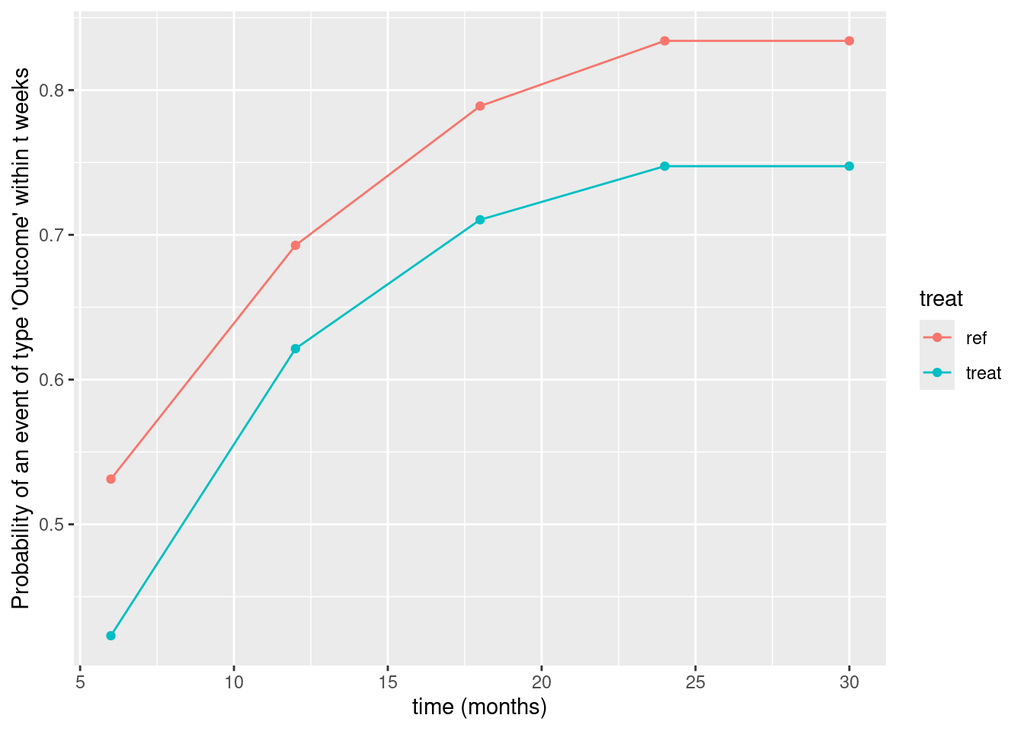

```r
  temp1[,t := 6*time_horizon] ## get t in weeks
  temp2[,t := 6*time_horizon] ## get t in weeks
  temp1$treat <- "treat"
  temp2$treat <- "ref"
  temp <- rbind(temp1,temp2)
  ggplot(temp, aes(x=t, y=estimate, color=treat)) + geom_line() + geom_point() + xlab("time (months)")+ylab("Probability of an event of type 'Outcome' within t weeks")
```

# Summararies

```r
summary(fit_treat)
```

```
##    time_horizon Target_parameter  estimate    std.err     lower     upper
##           <int>           <char>     <num>      <num>     <num>     <num>
## 1:            1        Risk(A=1) 0.4230298 0.02451528 0.3749807 0.4710788
## 2:            2        Risk(A=1) 0.6213690 0.02529421 0.5717933 0.6709448
## 3:            3        Risk(A=1) 0.7104148 0.02481847 0.6617715 0.7590581
## 4:            4        Risk(A=1) 0.7474477 0.02416836 0.7000786 0.7948169
## 5:            5        Risk(A=1) 0.7474477 0.02416836 0.7000786 0.7948169
##           pvalue
##            <num>
## 1:  1.012790e-66
## 2: 2.942309e-133
## 3: 3.335727e-180
## 4: 5.227522e-210
## 5: 5.227522e-210
```

```r
summary(fit_ref)
```

```
##    time_horizon Target_parameter  estimate    std.err     lower     upper
##           <int>           <char>     <num>      <num>     <num>     <num>
## 1:            1        Risk(A=1) 0.5312245 0.02403067 0.4841253 0.5783237
## 2:            2        Risk(A=1) 0.6927624 0.02304178 0.6476014 0.7379235
## 3:            3        Risk(A=1) 0.7889666 0.02067002 0.7484541 0.8294790
## 4:            4        Risk(A=1) 0.8340121 0.01895736 0.7968563 0.8711678
## 5:            5        Risk(A=1) 0.8340121 0.01895736 0.7968563 0.8711678
##           pvalue
##            <num>
## 1: 2.760748e-108
## 2: 1.369631e-198
## 3:  0.000000e+00
## 4:  0.000000e+00
## 5:  0.000000e+00
```